# Exploring Euryarchaeota BLAST

2023-05-17

# Euryarchaeota in the Ocean

I was interested in seeing how similar would Marine Group lll Euryarchaeota would be to their neighbors in Euryarchaeota, specifically to Haloarchaea. I chose two reference genomes for to use for the BLAST. The first was DS2 or also known as Haloferax Volcanii and the second was Haloferax Marinum. I chose H. volcanii because it is a model for haloarchaea and I chose H marinum because it was low salt-tolerant haloarchaea isolated from seawater and sediment. Below I am attaching the protein names i used with names/origin of the organism.

## Respective Protein Names

1. GCA_028346035.1: Marine Group III euryarchaeote Archaea; Candidatus Thermoplasmatota; Thermoplasmata; Candidatus Thermoprofundales.
2. GCA_028345155.1: Marine Group III euryarchaeote Archaea; Candidatus Thermoplasmatota; Thermoplasmata; Candidatus Thermoprofundales.
3. GCA_028343655.1: Marine Group III euryarchaeote Archaea; Candidatus Thermoplasmatota; Thermoplasmata; Candidatus Thermoprofundales.
4. GCA_012964945.1: Marine Group III euryarchaeote Archaea; Candidatus Thermoplasmatota; Thermoplasmata; Candidatus Thermoprofundales.
5. GCA_012963685.1: Marine Group III euryarchaeote Archaea; Candidatus Thermoplasmatota; Thermoplasmata; Candidatus Thermoprofundales.
6. GCA_012959635.1: Marine Group III euryarchaeote Archaea; Candidatus Thermoplasmatota; Thermoplasmata; Candidatus Thermoprofundales.
7. GCA_009674625.1: Haloferax Marinum
8. GCA_000025685.1: Haloferax Volcanii

# Loading Libraries

Remember to load your libraries

# Making a Database for DS2 or H.volcanii (Reference Genome)

```bash
/home/shared/ncbi-blast-2.11.0+/bin/makeblastdb \
-in ../eury_data_raw/ds2_protein.faa \
-dbtype prot \
-out ../eury_blastdb/ds2-protein
```

```
##
##
## Building a new DB, current time: 05/18/2023 10:46:11
## New DB name:   /home/shared/8TB_HDD_02/sggarcia/github/susan-compgenome/eury_blastdb/ds2-protein
## New DB title:  ../eury_data_raw/ds2_protein.faa
## Sequence type: Protein
## Deleted existing Protein BLAST database named /home/shared/8TB_HDD_02/sggarcia/github/susan-compgenome/eury_blastdb/ds2-protein
## Keep MBits: T
## Maximum file size: 1000000000B
## Adding sequences from FASTA; added 3927 sequences in 0.067739 seconds.
```

# Making a Database for H.marinum (Reference Genome)

```bash
/home/shared/ncbi-blast-2.11.0+/bin/makeblastdb \
-in ../eury_data_raw/GCA_009674625.1_protein.faa \
-dbtype prot \
-out ../eury_blastdb/hmar-protein
```

```
##
##
## Building a new DB, current time: 05/18/2023 10:46:12
## New DB name:   /home/shared/8TB_HDD_02/sggarcia/github/susan-compgenome/eury_blastdb/hmar-protein
## New DB title:  ../eury_data_raw/GCA_009674625.1_protein.faa
## Sequence type: Protein
## Deleted existing Protein BLAST database named /home/shared/8TB_HDD_02/sggarcia/github/susan-compgenome/eury_blastdb/hmar-protein
## Keep MBits: T
## Maximum file size: 1000000000B
## Adding sequences from FASTA; added 3370 sequences in 0.0612268 seconds.
```

# Exploring Files

## Finding the files within the folder

```bash
find ../eury_data_raw/ -type f -name "*.faa" -print0 | xargs -0 -I {} bash -c 'input_file="{}"; output_file="$(dirname "$input_file")/$(basename "$(dirname "$input_file")")_$(basename "$input_file")"; cp "$input_file" "$output_file"'
```

## How many files?

```bash
find ../eury_data_raw/ -type f -name "G*.faa" | wc -l
```

```
## 136
```

# BIG BLAST

## Blasting all the files for DS2

```bash
mkdir ../output/eury_bigblast-02

find ../eury_data_raw/ -type f -name "G*.faa" \
| xargs basename -s _protein.faa | xargs -I{} \
/home/shared/ncbi-blast-2.11.0+/bin/blastp \
-query ../eury_data_raw/{}/{}_protein.faa \
-db ../eury_blastdb/ds2-protein \
-out ../output/eury_bigblast-02/{}_ds2_blastp.tab \
-evalue 1E-20 \
-num_threads 40 \
-max_target_seqs 1 \
-outfmt 6
```

## Blasting all the files for H marinum

```bash
#mkdir ../output/eury_bigblast-02

find ../eury_data_raw/ -type f -name "G*.faa" \
| xargs basename -s _protein.faa | xargs -I{} \
/home/shared/ncbi-blast-2.11.0+/bin/blastp \
-query ../eury_data_raw/{}/{}_protein.faa \
-db ../eury_blastdb/hmar-protein \
-out ../output/eury_bigblast-02/{}_hmar_blastp.tab \
-evalue 1E-20 \
-num_threads 40 \
-max_target_seqs 1 \
-outfmt 6
```

# Comparisons

## Blasted to DS2

Comparison of DS2 to GCA_028346035.1 into a CSV file.

```r
# Read out the blast file into csv
eurybltabl1 <- read.csv("../output/eury_bigblast-02/GCA_028346035.1_ds2_blastp.tab", sep = '\t', header = FALSE)


#Extract columns desired
eurybltabl1_2.0 <- eurybltabl1[, c("V1", "V2", "V11", "V12")]

#Make into dataframe

eurybltabl1_2.0_df <- data_frame(eurybltabl1_2.0)
colnames(eurybltabl1_2.0_df) <- c("Query", "Database", "Eval", "Score")
```

Comparison of DS2 to GCA_028345155.1 into a CSV file.

```r
# Read out the blast file into csv
eurybltabl2 <- read.csv("../output/eury_bigblast-02/GCA_028345155.1_ds2_blastp.tab", sep = '\t', header = FALSE)


#Extract columns desired
eurybltabl2_2.0 <- eurybltabl2[, c("V1", "V2", "V11", "V12")]

#Make into dataframe

eurybltabl2_2.0_df <- data_frame(eurybltabl2_2.0)

colnames(eurybltabl2_2.0_df) <- c("Query", "Database", "Eval", "Score")
```

Comparison of DS2 to GCA_028343655.1 into a CSV file.

```r
# Read out the blast file into csv
eurybltabl3 <- read.csv("../output/eury_bigblast-02/GCA_028343655.1_ds2_blastp.tab", sep = '\t', header = FALSE)


#Extract columns desired
eurybltabl3_2.0 <- eurybltabl3[, c("V1", "V2", "V11", "V12")]

#Make into dataframe

eurybltabl3_2.0_df <- data_frame(eurybltabl3_2.0)

colnames(eurybltabl3_2.0_df) <- c("Query", "Database", "Eval", "Score")
```

Comparison of DS2 to GCA_012964945.1 into a CSV file.

```r
# Read out the blast file into csv
eurybltabl4 <- read.csv("../output/eury_bigblast-02/GCA_012964945.1_ds2_blastp.tab", sep = '\t', header = FALSE)

#Extract columns desired
eurybltabl4_2.0 <- eurybltabl4[, c("V1", "V2", "V11", "V12")]

#Make into dataframe

eurybltabl4_2.0_df <- data_frame(eurybltabl4_2.0)

colnames(eurybltabl4_2.0_df) <- c("Query", "Database", "Eval", "Score")
```

Comparison of DS2 to GCA_012963685.1 into a CSV file.

```r
# Read out the blast file into csv
eurybltabl5 <- read.csv("../output/eury_bigblast-02/GCA_012963685.1_ds2_blastp.tab", sep = '\t', header = FALSE)

#Extract columns desired
eurybltabl5_2.0 <- eurybltabl5[, c("V1", "V2", "V11", "V12")]

#Make into dataframe

eurybltabl5_2.0_df <- data_frame(eurybltabl5_2.0)

colnames(eurybltabl5_2.0_df) <- c("Query", "Database", "Eval", "Score")
```

Comparison of DS2 to GCA_012960615.1 into a CSV file.

```r
# Read out the blast file into csv
eurybltabl6 <- read.csv("../output/eury_bigblast-02/GCA_012960615.1_ds2_blastp.tab", sep = '\t', header = FALSE)

#Extract columns desired
eurybltabl6_2.0 <- eurybltabl6[, c("V1", "V2", "V11", "V12")]

#Make into dataframe

eurybltabl6_2.0_df <- data_frame(eurybltabl6_2.0)

colnames(eurybltabl6_2.0_df) <- c("Query", "Database", "Eval", "Score")
```

Comparison of DS2 to GCA_012959635.1 into a CSV file.

```r
# Read out the blast file into csv
eurybltabl7 <- read.csv("../output/eury_bigblast-02/GCA_012959635.1_ds2_blastp.tab", sep = '\t', header = FALSE)

#Extract columns desired
eurybltabl7_2.0 <- eurybltabl7[, c("V1", "V2", "V11", "V12")]

#Make into dataframe

eurybltabl7_2.0_df <- data_frame(eurybltabl7_2.0)

colnames(eurybltabl7_2.0_df) <- c("Query", "Database", "Eval", "Score")
```

Comparison of DS2 to GCA_009674625.1 into a CSV file.

```r
# Read out the blast file into csv
eurybltabl8 <- read.csv("../output/eury_bigblast-02/GCA_009674625.1_ds2_blastp.tab", sep = '\t', header = FALSE)

#Extract columns desired
eurybltabl8_2.0 <- eurybltabl8[, c("V1", "V2", "V11", "V12")]

#Make into dataframe

eurybltabl8_2.0_df <- data_frame(eurybltabl8_2.0)

colnames(eurybltabl8_2.0_df) <- c("Query", "Database", "Eval", "Score")
```

Comparison of DS2 to GCA_000025685.1 into a CSV file.

```r
# Read out the blast file into csv
eurybltabl9 <- read.csv("../output/eury_bigblast-02/GCA_000025685.1_ds2_blastp.tab", sep = '\t', header = FALSE)

#Extract columns desired
eurybltabl9_2.0 <- eurybltabl9[, c("V1", "V2", "V11", "V12")]

#Make into dataframe

eurybltabl9_2.0_df <- data_frame(eurybltabl9_2.0)

colnames(eurybltabl9_2.0_df) <- c("Query", "Database", "Eval", "Score")
```

## Blasted to H marinum

Comparison of H marinum to GCA_028346035.1 into a CSV file.

```r
# Read out the blast file into csv
hmarbltabl1 <- read.csv("../output/eury_bigblast-02/GCA_028346035.1_hmar_blastp.tab", sep = '\t', header = FALSE)


#Extract columns desired
hmarbltabl1_2.0 <- hmarbltabl1[, c("V1", "V2", "V11", "V12")]

#Make into dataframe

hmarbltabl1_2.0_df <- data_frame(hmarbltabl1_2.0)

colnames(hmarbltabl1_2.0_df) <- c("Query", "Database", "Eval", "Score")
```

Comparison of H marinum to GCA_028345155.1 into a CSV file.

```r
# Read out the blast file into csv
hmarbltabl2 <- read.csv("../output/eury_bigblast-02/GCA_028345155.1_hmar_blastp.tab", sep = '\t', header = FALSE)


#Extract columns desired
hmarbltabl2_2.0 <- hmarbltabl2[, c("V1", "V2", "V11", "V12")]

#Make into dataframe

hmarbltabl2_2.0_df <- data_frame(hmarbltabl2_2.0)

colnames(hmarbltabl2_2.0_df) <- c("Query", "Database", "Eval", "Score")
```

Comparison of H marinum to GCA_028343655.1 into a CSV file.

```r
# Read out the blast file into csv
hmarbltabl3 <- read.csv("../output/eury_bigblast-02/GCA_028343655.1_hmar_blastp.tab", sep = '\t', header = FALSE)


#Extract columns desired
hmarbltabl3_2.0 <- hmarbltabl3[, c("V1", "V2", "V11", "V12")]

#Make into dataframe

hmarbltabl3_2.0_df <- data_frame(hmarbltabl3_2.0)

colnames(hmarbltabl3_2.0_df) <- c("Query", "Database", "Eval", "Score")
```

Comparison of H marinum to GCA_012964945.1 into a CSV file.

```r
# Read out the blast file into csv
hmarbltabl4 <- read.csv("../output/eury_bigblast-02/GCA_012964945.1_hmar_blastp.tab", sep = '\t', header = FALSE)

#Extract columns desired
hmarbltabl4_2.0 <- hmarbltabl4[, c("V1", "V2", "V11", "V12")]

#Make into dataframe

hmarbltabl4_2.0_df <- data_frame(hmarbltabl4_2.0)

colnames(hmarbltabl4_2.0_df) <- c("Query", "Database", "Eval", "Score")
```

Comparison of H marinum to GCA_012963685.1 into a CSV file.

```r
# Read out the blast file into csv
hmarbltabl5 <- read.csv("../output/eury_bigblast-02/GCA_012963685.1_hmar_blastp.tab", sep = '\t', header = FALSE)

#Extract columns desired
hmarbltabl5_2.0 <- hmarbltabl5[, c("V1", "V2", "V11", "V12")]

#Make into dataframe

hmarbltabl5_2.0_df <- data_frame(hmarbltabl5_2.0)

colnames(hmarbltabl5_2.0_df) <- c("Query", "Database", "Eval", "Score")
```

Comparison of H marinum to GCA_012960615.1 into a CSV file.

```r
# Read out the blast file into csv
hmarbltabl6 <- read.csv("../output/eury_bigblast-02/GCA_012960615.1_hmar_blastp.tab", sep = '\t', header = FALSE)

#Extract columns desired
hmarbltabl6_2.0 <- hmarbltabl6[, c("V1", "V2", "V11", "V12")]

#Make into dataframe

hmarbltabl6_2.0_df <- data_frame(hmarbltabl6_2.0)

colnames(hmarbltabl6_2.0_df) <- c("Query", "Database", "Eval", "Score")
```

Comparison of H marinum to GCA_012959635.1 into a CSV file.

```r
# Read out the blast file into csv
hmarbltabl7 <- read.csv("../output/eury_bigblast-02/GCA_012959635.1_hmar_blastp.tab", sep = '\t', header = FALSE)

#Extract columns desired
hmarbltabl7_2.0 <- hmarbltabl7[, c("V1", "V2", "V11", "V12")]

#Make into dataframe

hmarbltabl7_2.0_df <- data_frame(hmarbltabl7_2.0)

colnames(hmarbltabl7_2.0_df) <- c("Query", "Database", "Eval", "Score")
```

Comparison of H marinum to GCA_009674625.1 into a CSV file.

```r
# Read out the blast file into csv
hmarbltabl8 <- read.csv("../output/eury_bigblast-02/GCA_009674625.1_hmar_blastp.tab", sep = '\t', header = FALSE)

#Extract columns desired
hmarbltabl8_2.0 <- hmarbltabl8[, c("V1", "V2", "V11", "V12")]

#Make into dataframe

hmarbltabl8_2.0_df <- data_frame(hmarbltabl8_2.0)

colnames(hmarbltabl8_2.0_df) <- c("Query", "Database", "Eval", "Score")
```

Comparison of H marinum to GCA_000025685.1 into a CSV file.

```r
# Read out the blast file into csv
hmarbltabl9 <- read.csv("../output/eury_bigblast-02/GCA_000025685.1_hmar_blastp.tab", sep = '\t', header = FALSE)

#Extract columns desired
hmarbltabl9_2.0 <- hmarbltabl9[, c("V1", "V2", "V11", "V12")]

#Make into dataframe

hmarbltabl9_2.0_df <- data_frame(hmarbltabl9_2.0)

colnames(hmarbltabl9_2.0_df) <- c("Query", "Database", "Eval", "Score")
```

# Setting up the Reference Genome Information needed

## DS2

DS2 fasta to tab-delimited

```bash
perl -e '$count=0; $len=0; while(<>) {s/\r?\n//; s/\t/ /g; if (s/^>//) { if ($. != 1) {print "\n"} s/ |$/\t/; $count++; $_ .= "\t";} else {s/ //g; $len += length($_)} print $_;} print "\n"; warn "\nConverted $count FASTA records in $. lines to tabular format\nTotal sequence length: $len\n\n";' ../eury_data_raw/ds2_protein.faa > ../output/ds2protein.tab
```

```
##
## Converted 3927 FASTA records in 19849 lines to tabular format
## Total sequence length: 1124001
```

Reading the file for ds2 protein to CSV file

```r
ds2csv <- read.csv("../output/ds2protein.tab", sep = '\t', header = TRUE)
colnames(ds2csv) <- c("Database", "Protein", "Coding_Sequence")
```

## H marinum

H. marinum fasta to tab-delimited

```bash
perl -e '$count=0; $len=0; while(<>) {s/\r?\n//; s/\t/ /g; if (s/^>//) { if ($. != 1) {print "\n"} s/ |$/\t/; $count++; $_ .= "\t";} else {s/ //g; $len += length($_)} print $_;} print "\n"; warn "\nConverted $count FASTA records in $. lines to tabular format\nTotal sequence length: $len\n\n";' ../eury_data_raw/GCA_009674625.1_protein.faa > ../output/hmarprotein.tab
```

```
##
## Converted 3370 FASTA records in 17366 lines to tabular format
## Total sequence length: 989692
```

Reading the file for H. marinum protein to CSV file

```r
hmarcsv <- read.csv("../output/hmarprotein.tab", sep = '\t', header = TRUE)
colnames(hmarcsv) <- c("Database", "Protein", "Coding_Sequence")
```

# Tables for each comparison to DS2

DS2 to GCA_028346035.1

```r
# Join the data frames
euryjoined1_df <- left_join(eurybltabl1_2.0_df, ds2csv, by = c("Database" = "Database")) %>%
  mutate(Organism = "035")

#You may print the table with kable
#kable(head(euryjoined1_df, n = 10), caption = "Joined data frame with kable formatting (first 10 rows)")

#Scrollable tables
datatable(head(euryjoined1_df), options = list(scrollX = TRUE, scrollY = "400px", scrollCollapse = TRUE, paging = FALSE))
```

|  | Query | Database | Eval | Score | Protein | Coding_Sequence | Organism |
| --- | --- | --- | --- | --- | --- | --- | --- |
| 1 | MDC0243053.1 | ADE04206.1 | 8.52e-98 | 301 | amidophosphoribosyltransferase [Haloferax volcanii DS2] | MVTGRDDSHHHIGGLTEKCGVVGVALGGRDAARPLYYSLYALQHRGQESAGIVTHDGFQQ…… | 035 |
| 2 | MDC0243055.1 | ADE02088.1 | 0 | 565 | acetyl-CoA synthetase (plasmid) [Haloferax volcanii DS2] | MAQGDAELEARLAEQDEFEPTEEFVAQANVSDAGIYDEFEENWPDCWERAADLLDWDADY…… | 035 |
| 3 | MDC0243056.1 | ADE04019.1 | 1.12e-158 | 457 | fumarate hydratase [Haloferax volcanii DS2] | MGDDDYRIERDSLGEMEVPVDAYWGAQTQRAVENFPISGITFGRRFVRALGVVKKAAAQA…… | 035 |
| 4 | MDC0243057.1 | ADE03285.1 | 9.15e-56 | 178 | putative oxidoreductase (aldo-keto reductase family protein) [Haloferax volcanii DS2] | MTENLASADDAPRANGMPMLGLGTWQNTNADECRNAVQTALEMGYRHIDTAQAYGNEAEV…… | 035 |
| 5 | MDC0243058.1 | ADE01569.1 | 1.02e-21 | 87.8 | putative inositol-1(or 4)-monophosphatase / fructose-1,6-bisphosphatase, archaeal-type (plasmid) [Haloferax volcanii DS2] | MVNDRYLWTAIRAAEVAGDELRARFESSSRERFRDRPADEAAEARITDVIAAAFPDDNVV…… | 035 |
| 6 | MDC0243059.1 | ADE02811.1 | 1.24e-40 | 137 | phosphoribosylformylglycinamidine synthase subunit PurQ [Haloferax volcanii DS2] | MIAVVQFGGSNCDRDAVRALSDLGFEAERVWHEDPLPEETTGIVLPGGFSYGDYLRGGAM…… | 035 |

DS2 to GCA_028345155.1

```r
# Join the data frames
euryjoined2_df <- left_join(eurybltabl2_2.0_df, ds2csv, by = c("Database" = "Database")) %>%
  mutate(Organism = "155")

# Print the table with kable
#kable(head(euryjoined2_df, n = 10), caption = "Joined data frame with kable formatting (first 10 rows)")

#Scrollable tables
datatable(head(euryjoined2_df), options = list(scrollX = TRUE, scrollY = "400px", scrollCollapse = TRUE, paging = FALSE))
```

|  | Query | Database | Eval | Score | Protein | Coding_Sequence | Organism |
| --- | --- | --- | --- | --- | --- | --- | --- |
| 1 | MDC0197011.1 | ADE05153.1 | 3.37e-38 | 127 | 23S rRNA (uridine-2'-O-) methyltransferase [Haloferax volcanii DS2] | MARKDHYYNKAKQEGYRARSAYKLKQLDGDAGLFGPGNTVVDLGAAPGGWLQVVSEEVGD…… | 155 |
| 2 | MDC0197013.1 | ADE03713.1 | 1.29e-82 | 256 | glutamyl-tRNA(Gln) amidotransferase subunit D [Haloferax volcanii DS2] | MNAGDRVRVTRADVTNEGVLMPSSTEDHLVVKLDGGYNVGIAREGADVDVLETDVYDIED…… | 155 |
| 3 | MDC0197014.1 | ADE02476.1 | 1.25e-54 | 181 | aminopeptidase [Haloferax volcanii DS2] | MDPRIREHARTIVDHSTSVEAGDNVVVSAPSVAEDLVTAIHELLGDRGANVVAMDANPRF…… | 155 |
| 4 | MDC0197020.1 | ADE02976.1 | 1.94e-25 | 102 | quinolinate synthase A [Haloferax volcanii DS2] | MVELQSVGFESELSLFKYDTLEQLPESHRDLDEAARSRRIAAAREALGDRVIVLGHNYQR…… | 155 |
| 5 | MDC0197022.1 | ADE05123.1 | 3.03e-111 | 334 | Fe-S cluster assembly complex protein SufB [Haloferax volcanii DS2] | MSSDQDHLKETDTEARFEFKKEQKAAFVAEKGLTEETIRVISEDKDEPEWMLERRLRALK…… | 155 |
| 6 | MDC0197023.1 | ADE04104.1 | 5.65e-84 | 249 | Fe-S cluster assembly complex ATPase SufC [Haloferax volcanii DS2] | MATLEIKNLHARVAEEDGEQILRGVDLEVKSGEIHALMGPNGSGKSTTSKIIAGHPAYEV…… | 155 |

DS2 to GCA_028343655.1

```r
# Join the data frames
euryjoined3_df <- left_join(eurybltabl3_2.0_df, ds2csv, by = c("Database" = "Database")) %>%
  mutate(Organism = "655")

# Print the table with kable
#kable(head(euryjoined3_df, n = 10), caption = "Joined data frame with kable formatting (first 10 rows)")

#Scrollable tables
datatable(head(euryjoined3_df), options = list(scrollX = TRUE, scrollY = "400px", scrollCollapse = TRUE, paging = FALSE))
```

|  | Query | Database | Eval | Score | Protein | Coding_Sequence | Organism |
| --- | --- | --- | --- | --- | --- | --- | --- |
| 1 | MDC0161237.1 | ADE03423.2 | 4.53e-24 | 96.7 | KaiC-type circadian clock protein CirB [Haloferax volcanii DS2] | MSDDDDWFERALRETDDGETDADDADPEESEQRDDGETDVGDADSGSAAESDAPDSSVTG…… | 655 |
| 2 | MDC0161244.1 | ADE03982.1 | 1.84e-63 | 195 | 4-phosphopantoate--beta-alanine ligase [Haloferax volcanii DS2] | MSDIEIPESHPRYQSLLTRHRIEEGVEKGITSRQGLIAQGRGEAFDYLLGERTLPSSDEA…… | 655 |
| 3 | MDC0161248.1 | ADE03059.1 | 8.51e-27 | 103 | rhodanese domain protein / beta-lactamase domain protein [Haloferax volcanii DS2] | MSKLLHQLTVGELADRVDAGESFTVVDTRPPESFESWHIEGAVNVPFHPVDGLGGDWDWD…… | 655 |
| 4 | MDC0161252.1 | ADE04937.1 | 3.08e-39 | 145 | deoxyribodipyrimidine photo-lyase [Haloferax volcanii DS2] | MQLHWHRRDLRVADNRGLATAAEAGPVAPLFVFDRDVLDHAGAPRVRYLLDALAELRGAY…… | 655 |
| 5 | MDC0161253.1 | ADE03363.1 | 8.51e-80 | 244 | threonine aldolase [Haloferax volcanii DS2] | MIDLRSDTVTLPSDEMREAARDAAVGDDVYGDDPTVNELEARAAELVGKEAALFVPSGTM…… | 655 |
| 6 | MDC0161255.1 | ADE04745.1 | 3.93e-140 | 414 | glycine--tRNA ligase [Haloferax volcanii DS2] | MSEGDESAALTELAKRRGFFFGSSEAYGGVGGFYTYGPQGAALKSNVEEAWRERFAVQEG…… | 655 |

DS2 to GCA_012964945.1

```r
# Join the data frames
euryjoined4_df <- left_join(eurybltabl4_2.0_df, ds2csv, by = c("Database" = "Database")) %>%
  mutate(Organism = "945")

# Print the table with kable
#kable(head(euryjoined4_df, n = 10), caption = "Joined data frame with kable formatting (first 10 rows)")

#Scrollable tables
datatable(head(euryjoined4_df), options = list(scrollX = TRUE, scrollY = "400px", scrollCollapse = TRUE, paging = FALSE))
```

|  | Query | Database | Eval | Score | Protein | Coding_Sequence | Organism |
| --- | --- | --- | --- | --- | --- | --- | --- |
| 1 | HIA97555.1 | ADE02657.1 | 1.75e-36 | 127 | cell division protein FtsZ, type II [Haloferax volcanii DS2] | MQDIVREAMERDEAERQTQSSLEDSDDQFGDPRIVIVGAGGAGNNTINRLYNIGVEGADT…… | 945 |
| 2 | HIA97557.1 | ADE04813.1 | 1.29e-41 | 139 | putative tRNA 2-thiolation protein NcsA [Haloferax volcanii DS2] | MECDKCGRDAVMHAAYSGAHLCDDHFCASVEKRVRRRIREDNMLPRDASPENPQTWVIGL…… | 945 |
| 3 | HIA97560.1 | ADE04246.1 | 7.5e-46 | 150 | ABC-type transport system ATP-binding protein (probable substrate macrolides) [Haloferax volcanii DS2] | MSVIELADVVKRYQNGEEVIAALDHVDFRADRGEMVTIIGPSGSGKSTMLNMIGLLDTPT…… | 945 |
| 4 | HIA97562.1 | ADE03365.1 | 9.73e-24 | 101 | DUF2070 family protein [Haloferax volcanii DS2] | MTSTQSDLAGLSRFIFRAPSWYTSLGFALLVAAMAGIGAFDSGDLAGSWRGIFFIGRDAW…… | 945 |
| 5 | HIA97565.1 | ADE02891.1 | 9.03e-89 | 278 | threonine--tRNA ligase [Haloferax volcanii DS2] | MSDIAVILPDGTELSVEEGATVRDAAFAIGPGLGKDTVAGVVDGELVDKETPLHDGADLV…… | 945 |
| 6 | HIA97566.1 | ADE01598.1 | 6.99e-43 | 155 | SSSF family transport protein (plasmid) [Haloferax volcanii DS2] | MVSSTVALGLTVATLVAFTGVGVWFSRGRVGSVEDLISARDSAGSRRTTATLVASVMGVW…… | 945 |

DS2 to GCA_012963685.1

```r
# Join the data frames
euryjoined5_df <- left_join(eurybltabl5_2.0_df, ds2csv, by = c("Database" = "Database")) %>%
  mutate(Organism = "685")

# Print the table with kable
# kable(head(euryjoined5_df, n = 10), caption = "Joined data frame with kable formatting (first 10 rows)")

#Scrollable tables
datatable(head(euryjoined5_df), options = list(scrollX = TRUE, scrollY = "400px", scrollCollapse = TRUE, paging = FALSE))
```

|  | Query | Database | Eval | Score | Protein | Coding_Sequence | Organism |
| --- | --- | --- | --- | --- | --- | --- | --- |
| 1 | HIC61122.1 | ADE02515.1 | 4.94e-105 | 307 | DNA topoisomerase 6 subunit A [Haloferax volcanii DS2] | MASDQQTSEERARERLIDLAAEFYDQFDAGEIPHMTLPTRTKSNIEYDEDANVWVYGDRT…… | 685 |
| 2 | HIC61126.1 | ADE02476.1 | 3.84e-54 | 179 | aminopeptidase [Haloferax volcanii DS2] | MDPRIREHARTIVDHSTSVEAGDNVVVSAPSVAEDLVTAIHELLGDRGANVVAMDANPRF…… | 685 |
| 3 | HIC61127.1 | ADE03713.1 | 6.94e-82 | 254 | glutamyl-tRNA(Gln) amidotransferase subunit D [Haloferax volcanii DS2] | MNAGDRVRVTRADVTNEGVLMPSSTEDHLVVKLDGGYNVGIAREGADVDVLETDVYDIED…… | 685 |
| 4 | HIC61132.1 | ADE02671.1 | 2.07e-62 | 199 | tyrosine--tRNA ligase [Haloferax volcanii DS2] | MDAYDLITRNASEVVTEDEVRALADDPEGKRAYVGYEPSGVLHIGHMLTANKLIDLQAAG…… | 685 |
| 5 | HIC61136.1 | ADE01717.1 | 3.59e-49 | 159 | putative oxidoreductase (short-chain dehydrogenase family) (plasmid) [Haloferax volcanii DS2] | MSRLDGSVALVTGASSGIGNAIAAAFGREGATVVVADVRREPKLDDERSVFEKLDDTGAE…… | 685 |
| 6 | HIC61139.1 | ADE03610.2 | 1.54e-22 | 92.8 | M20 family amidohydrolase [Haloferax volcanii DS2] | MSHRATMDDLVSLRRDLHRHPEPAWCEFYTTARLVDELETRDLDALYVGPEILDADERMA…… | 685 |

DS2 to GCA_012960615.1

```r
# Join the data frames
euryjoined6_df <- left_join(eurybltabl6_2.0_df, ds2csv, by = c("Database" = "Database")) %>%
  mutate(Organism = "615")

# Print the table with kable
#kable(head(euryjoined6_df, n = 10), caption = "Joined data frame with kable formatting (first 10 rows)")

#Scrollable tables
datatable(head(euryjoined6_df), options = list(scrollX = TRUE, scrollY = "400px", scrollCollapse = TRUE, paging = FALSE))
```

|  | Query | Database | Eval | Score | Protein | Coding_Sequence | Organism |
| --- | --- | --- | --- | --- | --- | --- | --- |
| 1 | HIG62905.1 | ADE02239.1 | 1.05e-56 | 172 | peptide methionine sulfoxide reductase MsrA (S-form specific) (plasmid) [Haloferax volcanii DS2] | MGSTQTATFGGGCFWCVEAAFKELDGISEVTSGYAGGETENPSYEQVCSGSTGHAEVVQVDYDPAVVGYDELLDVFFAVHDPTQLNRQGPDVGTQYRSIVLFHDDEQKRQASAYIDALDEEYDDEVVTELVPLETFYEAEEHHQDYFEKVSTADGNTNDAYCQFNVVPKIEKVREKFADKVKAEAEPDA | 615 |
| 2 | HIG62907.1 | ADE03003.1 | 2.34e-177 | 513 | translation initiation factor aIF-5B (bacterial-type IF2) [Haloferax volcanii DS2] | MSDTDSTSQSDTLRTPIVAVLGHVDHGKTSLLDKIRGSAVSEGEAGAITQHIGATAVPLD…… | 615 |
| 3 | HIG62909.1 | ADE04640.1 | 4.69e-30 | 102 | enamine/imine deaminase [Haloferax volcanii DS2] | MKRVIETDEAPAAVGAYSQATTNGSLLYTAGQIPLTPDGELLDDEDIATQTTQSLDNVMAILAEAGADATDVLKTTVFLADIDDFDEMNETYATYFDEEPPARSAVEVGNLPKGVGVEIEAVAVVDEE | 615 |
| 4 | HIG62917.1 | ADE03982.1 | 3.43e-63 | 194 | 4-phosphopantoate--beta-alanine ligase [Haloferax volcanii DS2] | MSDIEIPESHPRYQSLLTRHRIEEGVEKGITSRQGLIAQGRGEAFDYLLGERTLPSSDEA…… | 615 |
| 5 | HIG62919.1 | ADE04757.1 | 3.69e-67 | 209 | GalE family epimerase/dehydratase [Haloferax volcanii DS2] | MSLELSDKRVLVTGGAGLVGSHLAAHLSEDNYVVVADDLSKGDREQVPDGVEFVQADMTD…… | 615 |
| 6 | HIG62924.1 | ADE04608.1 | 3.17e-104 | 320 | tRNA-guanine(15) transglycosylase [Haloferax volcanii DS2] | MRDHFELRDGDLAGRIGRLSVPRAGVTVETPALLPVVNPNIDTISPARLESEFGAEILIT…… | 615 |

DS2 to GCA_012959635.1

```r
# Join the data frames
euryjoined7_df <- left_join(eurybltabl7_2.0_df, ds2csv, by = c("Database" = "Database")) %>%
  mutate(Organism = "635")

# Print the table with kable
#kable(head(euryjoined7_df, n = 10), caption = "Joined data frame with kable formatting (first 10 rows)")

#Scrollable tables
datatable(head(euryjoined7_df), options = list(scrollX = TRUE, scrollY = "400px", scrollCollapse = TRUE, paging = FALSE))
```

|  | Query | Database | Eval | Score | Protein | Coding_Sequence | Organism |
| --- | --- | --- | --- | --- | --- | --- | --- |
| 1 | HIF36803.1 | ADE02312.1 | 1.47e-62 | 197 | putative GTP-binding protein [Haloferax volcanii DS2] | MIFESLPTTPRSDELIDKAFSRAARTGRAKQNKLEAQQSMLQTASNILSDNLENVVVEWP…… | 635 |
| 2 | HIF36804.1 | ADE02810.1 | 1.58e-163 | 462 | isocitrate dehydrogenase (NADP) [Haloferax volcanii DS2] | MSYDQIEVPDDGEKITVDEETGELSVPDNPIIPIIHGDGIGTDVGPAAQKVLDAAAEATG…… | 635 |
| 3 | HIF36805.1 | ADE02795.1 | 3.98e-35 | 126 | proline dehydrogenase [Haloferax volcanii DS2] | MIPPIASRFVAGESAAGALDHARRMNDDGVAVILNLLGEHYAERAPADEDAAAYVDLVED…… | 635 |
| 4 | HIF36807.1 | ADE04813.1 | 3.14e-57 | 184 | putative tRNA 2-thiolation protein NcsA [Haloferax volcanii DS2] | MECDKCGRDAVMHAAYSGAHLCDDHFCASVEKRVRRRIREDNMLPRDASPENPQTWVIGL…… | 635 |
| 5 | HIF36809.1 | ADE02657.1 | 3.14e-67 | 214 | cell division protein FtsZ, type II [Haloferax volcanii DS2] | MQDIVREAMERDEAERQTQSSLEDSDDQFGDPRIVIVGAGGAGNNTINRLYNIGVEGADT…… | 635 |
| 6 | HIF36813.1 | ADE03415.1 | 1.03e-25 | 91.3 | 30S ribosomal protein S6e [Haloferax volcanii DS2] | MAEFMVVVADPDSGATYQVDVEGQDANRFLGRDLGDEVDGAAVGLDGFTLELTGGSDKAGRPMHPDVPGGALKEILAEDGIGYKPSRDGERKRVTVRGREVSDETVQINAKVVAGEGDVAAAFGEGDDEEADE | 635 |

DS2 to GCA_009674625.1

```r
# Join the data frames
euryjoined8_df <- left_join(eurybltabl8_2.0_df, ds2csv, by = c("Database" = "Database")) %>%
  mutate(Organism = "625")

# Print the table with kable
# kable(head(euryjoined8_df, n = 10), caption = "Joined data frame with kable formatting (first 10 rows)")

#Scrollable tables
datatable(head(euryjoined8_df), options = list(scrollX = TRUE, scrollY = "400px", scrollCollapse = TRUE, paging = FALSE))
```

|  | Query | Database | Eval | Score | Protein | Coding_Sequence | Organism |
| --- | --- | --- | --- | --- | --- | --- | --- |
| 1 | MRW94958.1 | ADE02501.1 | 2.64e-73 | 211 | uncharacterized protein HVO_2850 [Haloferax volcanii DS2] | MTNLPDGWTLWNDEHEGRRILAFRPDVFNESAFPAECMPTVFVWNGSRANRPGATQIRTKTWHAVLYLEPEIEVVVEEFDSREAAVDGATDIAGRFADGEIDYRSAYQVPREDYFEKLDELTGREP | 625 |
| 2 | MRW94959.1 | ADE03553.1 | 1.11e-97 | 275 | UPF0179 family protein [Haloferax volcanii DS2] | MTSVTLVGARLTDPGTEFVYHGESSACEGCPYRRQCLNLIEGVRYRVLDVRENTQVLDCAVHDEGVRAVEVEPAPVTANVPSKGAYAGSKASLQGPCPHTECPSHEYCVPEGAEFDQEYRIHDVLGDPPHDHCHLDRNLTLVEFEPADE | 625 |
| 3 | MRW94961.1 | ADE04761.1 | 9.37e-178 | 488 | AstE domain protein [Haloferax volcanii DS2] | MRIYELGDGTPEVSVVGSIHGDEPCGARAIERFVAEDPDVERPVKLIVANEEALAADERY…… | 625 |
| 4 | MRW94962.1 | ADE02255.1 | 4.98e-106 | 296 | DUF309 family protein [Haloferax volcanii DS2] | MDEHTRDPSVAPPLGNPTGWDDDLRMWEHATLRRAVEHGVRLFNAGDFHESHDCFEDEWYNYGAGTAESAFLHGMVQVAAGAYKHFDFENDVGMRSLFETALEYLSGVPSDFYGVDVDDVRATLRAALDDPTALHGWQIALDGHRATAYPADYDYVEGLDH | 625 |
| 5 | MRW94966.1 | ADE03634.1 | 1.46e-36 | 115 | uncharacterized protein HVO_2856 [Haloferax volcanii DS2] | MSDAIDLPARVRESLADSFDDARAAVRAGDAETALEHVEEASRVLGHKVPPSPLKEKLKHGVAAVERTAADEPLVASEYLRLMSQLVQP | 625 |
| 6 | MRW94967.1 | ADE03159.1 | 4.07e-156 | 432 | putative inositol-1(or 4)-monophosphatase / fructose-1,6-bisphosphatase, archaeal-type [Haloferax volcanii DS2] | MNELDARADRAQRAARDGGAVARRAFRTGIAVETKGGKTDVVTQADKDAQRRVVERIRGA…… | 625 |

DS2 to GCA_000025685.1

```r
# Join the data frames
euryjoined9_df <- left_join(eurybltabl9_2.0_df, ds2csv, by = c("Database" = "Database")) %>%
  mutate(Organism = "685")

# Print the table with kable
#kable(head(euryjoined9_df, n = 10), caption = "Joined data frame with kable formatting (first 10 rows)")

#Scrollable tables
datatable(head(euryjoined9_df), options = list(scrollX = TRUE, scrollY = "400px", scrollCollapse = TRUE, paging = FALSE))
```

|  | Query | Database | Eval | Score | Protein | Coding_Sequence | Organism |
| --- | --- | --- | --- | --- | --- | --- | --- |
| 1 | ADE01259.1 | ADE01259.1 | 0 | 527 |  |  | 685 |
| 2 | ADE01260.1 | ADE01260.1 | 0 | 727 | ABC-type transport system ATP-binding protein (probable substrate dipeptide/oligopeptide) (plasmid) [Haloferax volcanii DS2] | MRTSNQNDSDPDQDVVFEVRDLEVTFGTNRGESRVVRNVDFDIYRNETLGMVGESGSGKS…… | 685 |
| 3 | ADE01261.1 | ADE01261.1 | 0 | 509 | putative oxidoreductase (short-chain dehydrogenase family) (plasmid) [Haloferax volcanii DS2] | MVDRPTALEDPLDGRTALVTGASSGIGAATARVLAEDGADVCLAARRVERLESLADEIRD…… | 685 |
| 4 | ADE01262.1 | ADE01262.1 | 0 | 515 | ABC-type transport system permease protein (probable substrate molybdate) (plasmid) [Haloferax volcanii DS2] | MSHRQPNRRERGVTRLLPETWRGLTLLLAGVLLLYYLLPIGALVFAQSPASLATDVTNEV…… | 685 |
| 5 | ADE01263.1 | ADE01263.1 | 0 | 734 | DUF917 family protein (plasmid) [Haloferax volcanii DS2] | MKITTDNIDDFATGATVLGTGGGGDPYIGKLMAQQAIEEHGPVDLIDPRDVPDDALVIPS…… | 685 |
| 6 | ADE01264.1 | ADE01264.1 | 3.08e-159 | 435 | putative N4-hydroxy-1-aminopropane O-acetyltransferase (plasmid) [Haloferax volcanii DS2] | MTDAPATATANAATADAGREYAYRVRDETIDRTIAFAEVDPALDVDRLHAWLGSDHVKPY…… | 685 |

# Tables for each comparison to H marinum

H marinum to GCA_028346035.1

```r
# Join the data frames
hmarjoined1_df <- left_join(hmarbltabl1_2.0_df, hmarcsv, by = c("Database" = "Database")) %>%
  mutate(Organism = "035")

# Print the table with kable
#kable(head(hmarjoined1_df, n = 10), caption = "Joined data frame with kable formatting (first 10 rows)")

#Scrollable tables
datatable(head(hmarjoined1_df), options = list(scrollX = TRUE, scrollY = "400px", scrollCollapse = TRUE, paging = FALSE))
```

|  | Query | Database | Eval | Score | Protein | Coding_Sequence | Organism |
| --- | --- | --- | --- | --- | --- | --- | --- |
| 1 | MDC0243053.1 | MRW97873.1 | 1.05e-97 | 300 | amidophosphoribosyltransferase [Haloferax sp. MBLA0078] | MANGRDDSHHISGPTEKCGVVGVALDERSAARPLYYSLYALQHRGQESAGIVTHDGFQQH…… | 035 |
| 2 | MDC0243055.1 | MRW95893.1 | 0 | 557 | acetate--CoA ligase [Haloferax sp. MBLA0078] | MVDGDGDGELEARLVEQEEFEPSEEFVAQANVSDPEIYEEFEENWPQSWERAADMLDWDE…… | 035 |
| 3 | MDC0243056.1 | MRW95014.1 | 1.31e-166 | 478 | aspartate ammonia-lyase [Haloferax sp. MBLA0078] | MGDDDYRIEQDSLGEMQVPANAYWGAQTQRAVENFPISGITFGRRFVRALGVVKKAAAQA…… | 035 |
| 4 | MDC0243057.1 | MRW95903.1 | 1.18e-54 | 174 | aldo/keto reductase [Haloferax sp. MBLA0078] | MPMLGLGTWENTDPDECTNAVKTALEMGYRHIDTAQIYGNEAEVGAGIAAADVDREDIFL…… | 035 |
| 5 | MDC0243059.1 | MRW97341.1 | 1.23e-39 | 134 | phosphoribosylformylglycinamidine synthase I [Haloferax sp. MBLA0078] | MIAVVQFGGSNCDRDAVRALEDLGFEAERVWHEDPLPDEATGIMLPGGFSYGDYLRGGAM…… | 035 |
| 6 | MDC0243060.1 | MRW97891.1 | 9.96e-50 | 153 | nucleoside-diphosphate kinase [Haloferax sp. MBLA0078] | MSDTERTFVMVKPDGVQRGLIGDIVSRFEDRGLKMVGGKFMQISEELAHDHYGEHEGKPFFEGLVDFITSGPVFAMVWEGQDATRQVRRMMGETDPAESAPGTIRGDYGLDLGRNVIHGSDNEDEGANEREIDLFFDDDELVDYERIDETWLYE | 035 |

H marinum to GCA_028345155.1

```r
# Join the data frames
hmarjoined2_df <- left_join(hmarbltabl2_2.0_df, hmarcsv, by = c("Database" = "Database")) %>%
  mutate(Organism = "155")

# Print the table with kable
#kable(head(hmarjoined2_df, n = 10), caption = "Joined data frame with kable formatting (first 10 rows)")

#Scrollable tables
datatable(head(hmarjoined2_df), options = list(scrollX = TRUE, scrollY = "400px", scrollCollapse = TRUE, paging = FALSE))
```

|  | Query | Database | Eval | Score | Protein | Coding_Sequence | Organism |
| --- | --- | --- | --- | --- | --- | --- | --- |
| 1 | MDC0197011.1 | MRW96596.1 | 4.82e-40 | 132 | TRAM domain-containing protein [Haloferax sp. MBLA0078] | MARKDHYYNKAKQEGYRARSAYKLKQLDEEVGLFGPGNTVVDLGAAPGGWLQVASERVKA…… | 155 |
| 2 | MDC0197013.1 | MRW97640.1 | 1.74e-80 | 251 | Glu-tRNA(Gln) amidotransferase subunit GatD [Haloferax sp. MBLA0078] | MNAGDRVRVTRADVTNEGVLMPSSTDEYLVLKLEGGYNVGIDRADADVEVLESDVYDIEE…… | 155 |
| 3 | MDC0197014.1 | MRW96528.1 | 2.89e-56 | 184 | aminopeptidase [Haloferax sp. MBLA0078] | MDPRIREHAQTIVDHSTRVEEGDNVVVSAPAVADDLVTAVCELIGERGGYVVTTSSDPRF…… | 155 |
| 4 | MDC0197022.1 | MRW95933.1 | 1.39e-112 | 337 | Fe-S cluster assembly protein SufB [Haloferax sp. MBLA0078] | MSSDQDHLKETDTEARFEFKKEQKAAFAAEKGLTEETIRVISEDKDEPEWMLERRLRALK…… | 155 |
| 5 | MDC0197023.1 | MRW95934.1 | 2.69e-83 | 248 | ATP-binding cassette domain-containing protein [Haloferax sp. MBLA0078] | MATLEIKNLHARVAEDDGEQILRGVDLEVKSGEIHALMGPNGSGKSTTSKIIAGHPAYEV…… | 155 |
| 6 | MDC0197024.1 | MRW95932.1 | 4.82e-28 | 110 | Fe-S cluster assembly protein SufD [Haloferax sp. MBLA0078] | MSAQLPANLSAETVREISDARDEPEWLLEARLEALEALDTLELPDVIQTPGRRWTNLEAL…… | 155 |

H marinum to GCA_028343655.1

```r
# Join the data frames
hmarjoined3_df <- left_join(hmarbltabl3_2.0_df, hmarcsv, by = c("Database" = "Database")) %>%
  mutate(Organism = "655")

# Print the table with kable
#kable(head(hmarjoined3_df, n = 10), caption = "Joined data frame with kable formatting (first 10 rows)")

#Scrollable tables
datatable(head(hmarjoined3_df), options = list(scrollX = TRUE, scrollY = "400px", scrollCollapse = TRUE, paging = FALSE))
```

|  | Query | Database | Eval | Score | Protein | Coding_Sequence | Organism |
| --- | --- | --- | --- | --- | --- | --- | --- |
| 1 | MDC0161237.1 | MRW97478.1 | 1.24e-22 | 92 | KaiC domain-containing protein [Haloferax sp. MBLA0078] | MSDEDDWFERALREESDDADDTGEGTEPDTADPGSGTDSTDVAEDTEPPEHTDTELPGPD…… | 655 |
| 2 | MDC0161244.1 | MRW96127.1 | 1.74e-64 | 198 | phosphopantothenate/pantothenate synthetase [Haloferax sp. MBLA0078] | MSDIEIPESHPRYQSLLTRHRIEEGVDKGITSRQGLIAQGRGEAFDYLLGERTIPSADDA…… | 655 |
| 3 | MDC0161248.1 | MRW96539.1 | 1.38e-29 | 110 | MBL fold metallo-hydrolase [Haloferax sp. MBLA0078] | MDIESLTGPDDVASIGPEALQDRIARGDRVPVLDVRTEREYDKWRIESERLDDRNVPYYE…… | 655 |
| 4 | MDC0161252.1 | MRW97978.1 | 3e-37 | 140 | DASH family cryptochrome [Haloferax sp. MBLA0078] | MTRSIALVWFRRDLRLHDNAALVSACEAAHVVPVYCFDPREYGRRAFGGPDSFEFLKTGP…… | 655 |
| 5 | MDC0161253.1 | MRW96527.1 | 1.26e-84 | 256 | low specificity L-threonine aldolase [Haloferax sp. MBLA0078] | MIDLRSDTVTLPSDEMREAARDAAVGDDVYGDDPTVNELEARAAELVGMEAALYVPSGTM…… | 655 |
| 6 | MDC0161255.1 | MRW96714.1 | 8.05e-135 | 400 | glycine--tRNA ligase [Haloferax sp. MBLA0078] | MSEGAESAALAELAKRRGFFFGSSEAYGGVGGFYTYGPQGAALKSNVEEAWRERFAVQEG…… | 655 |

H marinum to GCA_012964945.1

```r
# Join the data frames
hmarjoined4_df <- left_join(hmarbltabl4_2.0_df, hmarcsv, by = c("Database" = "Database")) %>%
  mutate(Organism = "945")

# Print the table with kable
#kable(head(hmarjoined4_df, n = 10), caption = "Joined data frame with kable formatting (first 10 rows)")

#Scrollable tables
datatable(head(hmarjoined4_df), options = list(scrollX = TRUE, scrollY = "400px", scrollCollapse = TRUE, paging = FALSE))
```

|  | Query | Database | Eval | Score | Protein | Coding_Sequence | Organism |
| --- | --- | --- | --- | --- | --- | --- | --- |
| 1 | HIA97555.1 | MRW96229.1 | 7.45e-36 | 125 | cell division protein FtsZ [Haloferax sp. MBLA0078] | MQDIVREAMERDEAERKTKLEDTDDDQFGDPRIVIVGCGGAGNNTINRLYNIGVEGADTV…… | 945 |
| 2 | HIA97557.1 | MRW96230.1 | 4.3e-42 | 140 | TIGR00269 family protein [Haloferax sp. MBLA0078] | MECDKCSRDAVMHAAYSGAHLCDDHFCASVEKRVRRRIREDNMLPRDATPEDPQTWVIGL…… | 945 |
| 3 | HIA97560.1 | MRW95824.1 | 8.81e-49 | 157 | ATP-binding cassette domain-containing protein [Haloferax sp. MBLA0078] | MSHIIELQHVWKRYDTGGEIVEALRDVDFHADPGEFVTVMGPSGSGKSTMLNVLGLLDTP…… | 945 |
| 4 | HIA97562.1 | MRW96159.1 | 2.61e-23 | 100 | DUF2070 family protein [Haloferax sp. MBLA0078] | MTSTQSDLAGLSRFIFRAPKWYTSLGFALLVAAMAGIAAFDSGDLESSWRGIFFLGRDAW…… | 945 |
| 5 | HIA97565.1 | MRW95104.1 | 4.31e-90 | 281 | threonine--tRNA ligase [Haloferax sp. MBLA0078] | MSDIAVTLPDGSELSVEEGATVRDAAFAIGPGLGKDTVAGVVDGELVDKETPLEDGAELV…… | 945 |
| 6 | HIA97570.1 | MRW97069.1 | 2.19e-62 | 200 | bifunctional N(6)-L-threonylcarbamoyladenine synthase/serine/threonine protein kinase [Haloferax sp. MBLA0078] | MRILGIEGTAWAASAAVFETDDPDALTSATDRTPDPAADHVFIESNPYQPDSGGIHPREA…… | 945 |

H marinum to GCA_012963685.1

```r
# Join the data frames
hmarjoined5_df <- left_join(hmarbltabl5_2.0_df, hmarcsv, by = c("Database" = "Database")) %>%
  mutate(Organism = "685")

# Print the table with kable
#kable(head(hmarjoined5_df, n = 10), caption = "Joined data frame with kable formatting (first 10 rows)")

#Scrollable tables
datatable(head(hmarjoined5_df), options = list(scrollX = TRUE, scrollY = "400px", scrollCollapse = TRUE, paging = FALSE))
```

|  | Query | Database | Eval | Score | Protein | Coding_Sequence | Organism |
| --- | --- | --- | --- | --- | --- | --- | --- |
| 1 | HIC61122.1 | MRW95207.1 | 1.39e-107 | 313 | DNA topoisomerase IV subunit A [Haloferax sp. MBLA0078] | MASDSKTSEEIARERLIDLAAEFYDQFDRGEIPEMKLPTRTKSNIEYDEDSHVWVYGDRT…… | 685 |
| 2 | HIC61126.1 | MRW96528.1 | 1.35e-56 | 186 | aminopeptidase [Haloferax sp. MBLA0078] | MDPRIREHAQTIVDHSTRVEEGDNVVVSAPAVADDLVTAVCELIGERGGYVVTTSSDPRF…… | 685 |
| 3 | HIC61127.1 | MRW97640.1 | 7.74e-77 | 241 | Glu-tRNA(Gln) amidotransferase subunit GatD [Haloferax sp. MBLA0078] | MNAGDRVRVTRADVTNEGVLMPSSTDEYLVLKLEGGYNVGIDRADADVEVLESDVYDIEE…… | 685 |
| 4 | HIC61132.1 | MRW96630.1 | 1.36e-64 | 204 | tyrosine--tRNA ligase [Haloferax sp. MBLA0078] | MDAYDLITRNASEVVTEDEVRALADDPEGKRAYVGYEPSGVLHIGHMLTANKLIDLQDAG…… | 685 |
| 5 | HIC61136.1 | MRW95313.1 | 1.07e-43 | 144 | SDR family oxidoreductase [Haloferax sp. MBLA0078] | MKGIQGKTALVTGGASGIGRATALRFGEEGANVVVSDVQVDAGNQVVSEIENDGGEAVFI…… | 685 |
| 6 | HIC61138.1 | MRW97404.1 | 1.99e-22 | 95.9 | MFS transporter [Haloferax sp. MBLA0078] | MQPQTPVDSDGPAETREQNSGFRYWAPLVTVSVAMFIGTIDSSMMNVAVPAIVSDLQTDV…… | 685 |

H marinum to GCA_012960615.1

```r
# Join the data frames
hmarjoined6_df <- left_join(hmarbltabl6_2.0_df, hmarcsv, by = c("Database" = "Database")) %>%
  mutate(Organism = "615")

# Print the table with kable
#kable(head(hmarjoined6_df, n = 10), caption = "Joined data frame with kable formatting (first 10 rows)")

#Scrollable tables
datatable(head(hmarjoined6_df), options = list(scrollX = TRUE, scrollY = "400px", scrollCollapse = TRUE, paging = FALSE))
```

|  | Query | Database | Eval | Score | Protein | Coding_Sequence | Organism |
| --- | --- | --- | --- | --- | --- | --- | --- |
| 1 | HIG62905.1 | MRW98107.1 | 2.94e-58 | 176 | peptide-methionine (S)-S-oxide reductase MsrA [Haloferax sp. MBLA0078] | MGTTQTATFGGGCFWCIEAAFKELDGITDVTSGYAGGSVENPTYKQVCSGDTGHAEVVQLEFDPDVVAYDELLDVFFAVHDPTQLNRQGPDVGTQYRSVILYHDDDQRQVAEAYIEAVDESYDDDVVTELTSIETFYEAEEYHQDYFEKNPNDAYCQFHASPKVEKVREKFADKLAH | 615 |
| 2 | HIG62907.1 | MRW97138.1 | 6.19e-179 | 516 | translation initiation factor IF-2 [Haloferax sp. MBLA0078] | MSDTDSTSQSDTLRTPIVAVLGHVDHGKTSLLDKVRGSAVSEGEAGAITQHIGATAVPLE…… | 615 |
| 3 | HIG62908.1 | MRW96729.1 | 7.36e-30 | 121 | DEAD/DEAH box helicase [Haloferax sp. MBLA0078] | MAHANDASDDSDSERAWRFFPYDDPYPNQEAAMSGIADALDDERNVLLEGATGTGKTISA…… | 615 |
| 4 | HIG62909.1 | MRW96345.1 | 2.17e-28 | 97.4 | RidA family protein [Haloferax sp. MBLA0078] | MKRVINTDEAPAAVGAYSQATTNGSLLYTAGQIPLTPDGELLDDEDIATQTEQALDNLLAILEEAGADAGDVLKTTVFLGDIGDFEEMNETYATYFDDEPPARSAVEVANLPKGVGVEIEAVAVVDEE | 615 |
| 5 | HIG62917.1 | MRW96127.1 | 1.22e-63 | 196 | phosphopantothenate/pantothenate synthetase [Haloferax sp. MBLA0078] | MSDIEIPESHPRYQSLLTRHRIEEGVDKGITSRQGLIAQGRGEAFDYLLGERTIPSADDA…… | 615 |
| 6 | HIG62919.1 | MRW95602.1 | 1.11e-61 | 195 | NAD-dependent epimerase/dehydratase family protein [Haloferax sp. MBLA0078] | MSLELSDKRVLVTGGAGLVGSHIAAYLADDNDVVVADDLSKGTRERVPDGVEFVEADMTD…… | 615 |

H marinum to GCA_012959635.1

```r
# Join the data frames
hmarjoined7_df <- left_join(hmarbltabl7_2.0_df, hmarcsv, by = c("Database" = "Database")) %>%
  mutate(Organism = "635")

# Print the table with kable
#kable(head(hmarjoined7_df, n = 10), caption = "Joined data frame with kable formatting (first 10 rows)")

#Scrollable tables
datatable(head(hmarjoined7_df), options = list(scrollX = TRUE, scrollY = "400px", scrollCollapse = TRUE, paging = FALSE))
```

|  | Query | Database | Eval | Score | Protein | Coding_Sequence | Organism |
| --- | --- | --- | --- | --- | --- | --- | --- |
| 1 | HIF36803.1 | MRW97094.1 | 1.2e-61 | 195 | GTP-binding protein [Haloferax sp. MBLA0078] | MIFESLPTTPRSDELIDKAFSRAARSGRAKQNKLEAQQSMLQTASNILSDNLENVVVEWP…… | 635 |
| 2 | HIF36804.1 | MRW97728.1 | 3.18e-163 | 462 | isocitrate dehydrogenase (NADP(+)) [Haloferax sp. MBLA0078] | MSYDQIEVPEDGEKITFEDGELSVPDNPIIPIIHGDGIGTDVGPAAQKVLDAAAEATGRS…… | 635 |
| 3 | HIF36805.1 | MRW96457.1 | 2.67e-36 | 129 | proline dehydrogenase [Haloferax sp. MBLA0078] | MIPPIASKFVAGETAAEALDHARATNDDGVAVILNLLGEHYHERGPADNDADQYVHLVED…… | 635 |
| 4 | HIF36807.1 | MRW96230.1 | 4.54e-55 | 178 | TIGR00269 family protein [Haloferax sp. MBLA0078] | MECDKCSRDAVMHAAYSGAHLCDDHFCASVEKRVRRRIREDNMLPRDATPEDPQTWVIGL…… | 635 |
| 5 | HIF36809.1 | MRW96229.1 | 6.19e-67 | 213 | cell division protein FtsZ [Haloferax sp. MBLA0078] | MQDIVREAMERDEAERKTKLEDTDDDQFGDPRIVIVGCGGAGNNTINRLYNIGVEGADTV…… | 635 |
| 6 | HIF36813.1 | MRW96959.1 | 2.79e-24 | 87.4 | 30S ribosomal protein S6e [Haloferax sp. MBLA0078] | MAEFMVVVADPDSGETHQFDVEGQDANRFLGRDLGDEVDGGAVGLDGFTLELTGGSDKAGRPMHPEVPGTSLKEILSEGGIGYAPSRDGERKRVTVRGRQVSEETVQINAKVVEGGDVAAALADDEDEEADE | 635 |

H marinum to GCA_009674625.1

```r
# Join the data frames
hmarjoined8_df <- left_join(hmarbltabl8_2.0_df, hmarcsv, by = c("Database" = "Database")) %>%
  mutate(Organism = "625")

# Print the table with kable
#kable(head(hmarjoined8_df, n = 10), caption = "Joined data frame with kable formatting (first 10 rows)")

#Scrollable tables
datatable(head(hmarjoined8_df), options = list(scrollX = TRUE, scrollY = "400px", scrollCollapse = TRUE, paging = FALSE))
```

|  | Query | Database | Eval | Score | Protein | Coding_Sequence | Organism |
| --- | --- | --- | --- | --- | --- | --- | --- |
| 1 | MRW94958.1 | MRW94958.1 | 4.36e-92 | 258 |  |  | 625 |
| 2 | MRW94959.1 | MRW94959.1 | 3.08e-110 | 306 | hypothetical protein GJR99_00010 [Haloferax sp. MBLA0078] | MTSVTLIGARLTDPGTEFVYRGESSACEGCPYRRQCLNLTEGVRYRVIGVRENTQVLDCAVHEEGVRAVEVETAAVRANVPSKGAYAGSKASLQGSCPHTECPSHQYCVPEGADFDQEYRISEVIGDPPHEHCYLDRNLTLVEFEAADE | 625 |
| 3 | MRW94960.1 | MRW94960.1 | 7.35e-154 | 421 | HAD-IA family hydrolase [Haloferax sp. MBLA0078] | MTTAVYFDLDLTLLQYTDDFETIFERSVPDAPDGAYERYVEVLFETFDDLSSTPYREAFS…… | 625 |
| 4 | MRW94961.1 | MRW94961.1 | 0 | 574 | succinylglutamate desuccinylase [Haloferax sp. MBLA0078] | MRIYELGDGTPEVSVVGSIHGDEPCGARAIERFVAEDPDVERPVKLIIANERALEEDVRY…… | 625 |
| 5 | MRW94962.1 | MRW94962.1 | 1.22e-121 | 336 | DUF309 domain-containing protein [Haloferax sp. MBLA0078] | MDEHTRDPSVAPPLGNPSGWNADTRMWEHATLRRAVEHGVRLFNASDFHESHDCFEDEWYNYGAGTTESAFLHGMVQVAAGAYKHFDFENDVGMRSLFETALQYLRGTPSDFYGVNVDDVRATLRAALDDPSVLHGWHITLDGQQATAYPVDYEYAAQLDH | 625 |
| 6 | MRW94963.1 | MRW94963.1 | 1.7e-42 | 128 | hypothetical protein GJR99_00030 [Haloferax sp. MBLA0078] | MSESVTECAYCGCDVHRHDPVFVEEVDGGERVSAGAFCNYACLSSYIDAEGLTIGATCEVPSE | 625 |

H marinum to GCA_000025685.1

```r
# Join the data frames
hmarjoined9_df <- left_join(hmarbltabl9_2.0_df, hmarcsv, by = c("Database" = "Database")) %>%
  mutate(Organism = "685")

# Print the table with kable
#kable(head(hmarjoined9_df, n = 10), caption = "Joined data frame with kable formatting (first 10 rows)")

#Scrollable tables
datatable(head(hmarjoined9_df), options = list(scrollX = TRUE, scrollY = "400px", scrollCollapse = TRUE, paging = FALSE))
```

|  | Query | Database | Eval | Score | Protein | Coding_Sequence | Organism |
| --- | --- | --- | --- | --- | --- | --- | --- |
| 1 | ADE01260.1 | MRW96898.1 | 6.34e-139 | 395 | ATP-binding cassette domain-containing protein [Haloferax sp. MBLA0078] | MTTDDPIIEIRNAAVTYDGGETFVLDHVSASIERGEILGIVGESGSGKSMFADSLLDAIP…… | 685 |
| 2 | ADE01261.1 | MRW95043.1 | 1.53e-93 | 272 | SDR family NAD(P)-dependent oxidoreductase [Haloferax sp. MBLA0078] | MRDDLTDRVALVTGASAGIGEATAHALAEVGANLVLLARREDRLLSIAEAVESEYGVETL…… | 685 |
| 3 | ADE01263.1 | MRW96929.1 | 0 | 662 | DUF917 family protein [Haloferax sp. MBLA0078] | MKITTDNIDDFATGATVLGTGGGGDPYIGKLMAEQAIEEHGPVELIDPREVPDDALVIPS…… | 685 |
| 4 | ADE01268.1 | MRW97659.1 | 7.21e-25 | 102 | MFS transporter [Haloferax sp. MBLA0078] | MKLSAIRRRKTGEVPWQSPTVQVVLASTLLAPLGVPLVAPALPVIRDVFVLTDAEASLLV…… | 685 |
| 5 | ADE01270.1 | MRW98145.1 | 7.29e-116 | 357 | AAA family ATPase [Haloferax sp. MBLA0078] | MTVTSRAANVSVEARNIGGIEHTHVEFEPGITILVGRNATNRTSFLQALMTALGSDRASL…… | 685 |
| 6 | ADE01275.1 | MRW95134.1 | 4.75e-21 | 90.9 | PQQ-binding-like beta-propeller repeat protein [Haloferax sp. MBLA0078] | MRRRQVLASLGVAALAGCTAPAFGGPRETDPLPGEDDDSAWAQQGPTPANQRRVPSVSVT…… | 685 |

# Joining all Datatables for DS2

```r
# Join the data frames
ds2joinedtotal_df <- bind_rows(euryjoined1_df, euryjoined2_df, euryjoined3_df, euryjoined4_df, euryjoined5_df, euryjoined6_df, euryjoined7_df, euryjoined8_df, euryjoined9_df)

# Print the table with kable
#kable(head(ds2joinedtotal_df, n = 10), caption = "Joined data frame with kable formatting (first 10 rows)")

#Scrollable tables
datatable(head(ds2joinedtotal_df), options = list(scrollX = TRUE, scrollY = "400px", scrollCollapse = TRUE, paging = FALSE))
```

|  | Query | Database | Eval | Score | Protein | Coding_Sequence | Organism |
| --- | --- | --- | --- | --- | --- | --- | --- |
| 1 | MDC0243053.1 | ADE04206.1 | 8.52e-98 | 301 | amidophosphoribosyltransferase [Haloferax volcanii DS2] | MVTGRDDSHHHIGGLTEKCGVVGVALGGRDAARPLYYSLYALQHRGQESAGIVTHDGFQQ…… | 035 |
| 2 | MDC0243055.1 | ADE02088.1 | 0 | 565 | acetyl-CoA synthetase (plasmid) [Haloferax volcanii DS2] | MAQGDAELEARLAEQDEFEPTEEFVAQANVSDAGIYDEFEENWPDCWERAADLLDWDADY…… | 035 |
| 3 | MDC0243056.1 | ADE04019.1 | 1.12e-158 | 457 | fumarate hydratase [Haloferax volcanii DS2] | MGDDDYRIERDSLGEMEVPVDAYWGAQTQRAVENFPISGITFGRRFVRALGVVKKAAAQA…… | 035 |
| 4 | MDC0243057.1 | ADE03285.1 | 9.15e-56 | 178 | putative oxidoreductase (aldo-keto reductase family protein) [Haloferax volcanii DS2] | MTENLASADDAPRANGMPMLGLGTWQNTNADECRNAVQTALEMGYRHIDTAQAYGNEAEV…… | 035 |
| 5 | MDC0243058.1 | ADE01569.1 | 1.02e-21 | 87.8 | putative inositol-1(or 4)-monophosphatase / fructose-1,6-bisphosphatase, archaeal-type (plasmid) [Haloferax volcanii DS2] | MVNDRYLWTAIRAAEVAGDELRARFESSSRERFRDRPADEAAEARITDVIAAAFPDDNVV…… | 035 |
| 6 | MDC0243059.1 | ADE02811.1 | 1.24e-40 | 137 | phosphoribosylformylglycinamidine synthase subunit PurQ [Haloferax volcanii DS2] | MIAVVQFGGSNCDRDAVRALSDLGFEAERVWHEDPLPEETTGIVLPGGFSYGDYLRGGAM…… | 035 |

# Joining all Datatables for H marinum

```r
# Join the data frames
hmar_joinedtotal_df <- bind_rows(hmarjoined1_df, hmarjoined2_df, hmarjoined3_df, hmarjoined4_df, hmarjoined5_df, hmarjoined6_df, hmarjoined7_df, hmarjoined8_df, hmarjoined9_df)

# Print the table with kable
#kable(head(hmar_joinedtotal_df, n = 10), caption = "Joined data frame with kable formatting (first 10 rows)")
#Scrollable tables
datatable(head(hmar_joinedtotal_df), options = list(scrollX = TRUE, scrollY = "400px", scrollCollapse = TRUE, paging = FALSE))
```

|  | Query | Database | Eval | Score | Protein | Coding_Sequence | Organism |
| --- | --- | --- | --- | --- | --- | --- | --- |
| 1 | MDC0243053.1 | MRW97873.1 | 1.05e-97 | 300 | amidophosphoribosyltransferase [Haloferax sp. MBLA0078] | MANGRDDSHHISGPTEKCGVVGVALDERSAARPLYYSLYALQHRGQESAGIVTHDGFQQH…… | 035 |
| 2 | MDC0243055.1 | MRW95893.1 | 0 | 557 | acetate--CoA ligase [Haloferax sp. MBLA0078] | MVDGDGDGELEARLVEQEEFEPSEEFVAQANVSDPEIYEEFEENWPQSWERAADMLDWDE…… | 035 |
| 3 | MDC0243056.1 | MRW95014.1 | 1.31e-166 | 478 | aspartate ammonia-lyase [Haloferax sp. MBLA0078] | MGDDDYRIEQDSLGEMQVPANAYWGAQTQRAVENFPISGITFGRRFVRALGVVKKAAAQA…… | 035 |
| 4 | MDC0243057.1 | MRW95903.1 | 1.18e-54 | 174 | aldo/keto reductase [Haloferax sp. MBLA0078] | MPMLGLGTWENTDPDECTNAVKTALEMGYRHIDTAQIYGNEAEVGAGIAAADVDREDIFL…… | 035 |
| 5 | MDC0243059.1 | MRW97341.1 | 1.23e-39 | 134 | phosphoribosylformylglycinamidine synthase I [Haloferax sp. MBLA0078] | MIAVVQFGGSNCDRDAVRALEDLGFEAERVWHEDPLPDEATGIMLPGGFSYGDYLRGGAM…… | 035 |
| 6 | MDC0243060.1 | MRW97891.1 | 9.96e-50 | 153 | nucleoside-diphosphate kinase [Haloferax sp. MBLA0078] | MSDTERTFVMVKPDGVQRGLIGDIVSRFEDRGLKMVGGKFMQISEELAHDHYGEHEGKPFFEGLVDFITSGPVFAMVWEGQDATRQVRRMMGETDPAESAPGTIRGDYGLDLGRNVIHGSDNEDEGANEREIDLFFDDDELVDYERIDETWLYE | 035 |

# Visualization

```r
# Summarize the data
ds2summarized_df <- ds2joinedtotal_df %>%
  group_by(Protein, Organism) %>%
  summarize(mean_value = mean(Score))
```

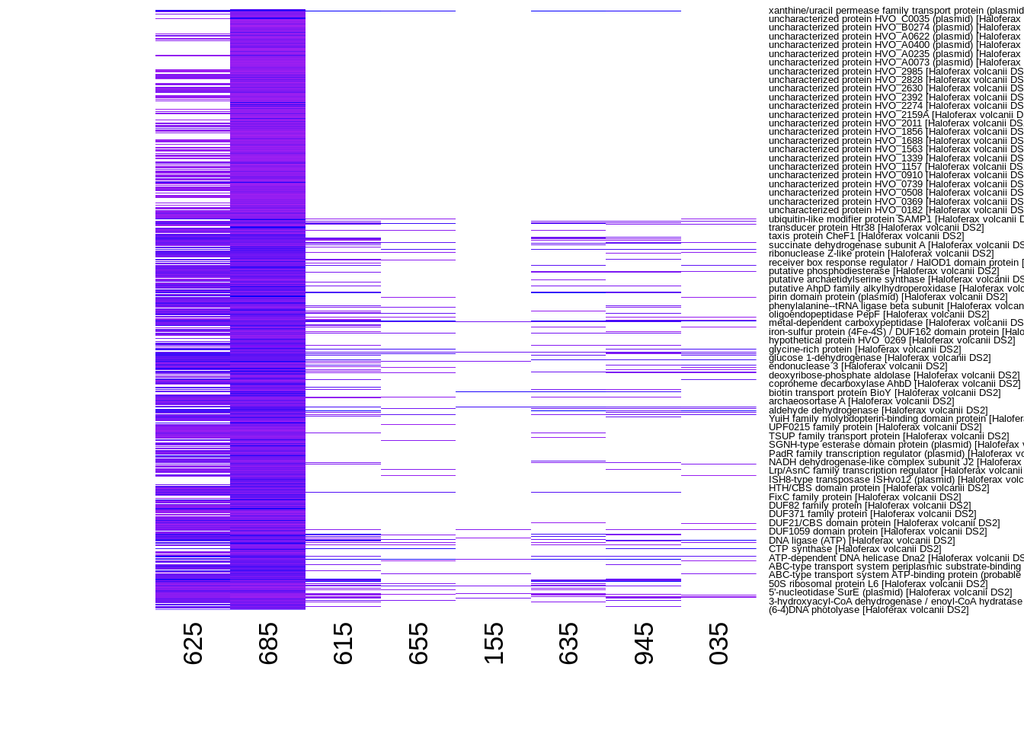

```r
# Create a wide-format table
ds2wide_df <- ds2summarized_df %>%
  pivot_wider(names_from = Organism, values_from = mean_value)

# Exclude non-numeric columns
ds2data_mat <- as.matrix(ds2wide_df[, -1])

# Define custom color palette
ds2my_palette <- colorRampPalette(c("purple", "blue", "magenta"))(n = 100)

# Generate the heatmap with custom colors and row names
heatmap(ds2data_mat, Rowv = NA, Colv = NA, col = ds2my_palette, scale = "column",
        labRow = ds2wide_df$Protein)
```

```r
# Summarize the data
hmar_summarized_df <- hmar_joinedtotal_df %>%
  group_by(Protein, Organism) %>%
  summarize(mean_value = mean(Score))
```

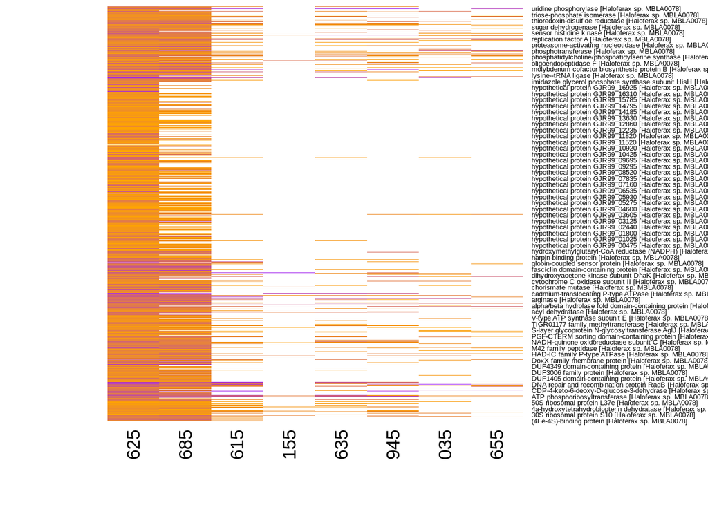

```r
# Create a wide-format table
wide_df <- hmar_summarized_df %>%
  pivot_wider(names_from = Organism, values_from = mean_value)

# Exclude non-numeric columns
data_mat <- as.matrix(wide_df[, -1])

# Define custom color palette
my_palette <- colorRampPalette(c("orange", "purple", "pink"))(n = 100)

# Generate the heatmap with custom colors and row names
heatmap(data_mat, Rowv = NA, Colv = NA, col = my_palette, scale = "column",
        labRow = wide_df$Protein)
```

## Joined Dataset 1 Protein Hits Figure

Joined Dataset 1 top Protein Hits

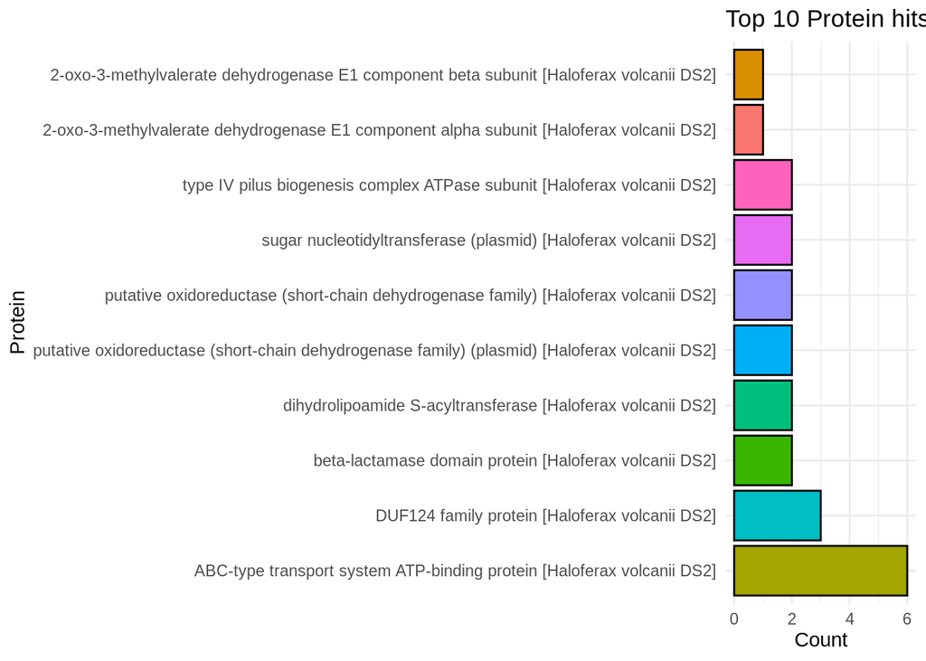

```r
# Read joined blast table with annotation table
joined1_df <- left_join(eurybltabl1_2.0_df, ds2csv, by = "Database")
#c("Database" = "Database"))

# Select the column of interest
column_name <- "Protein"  # Replace with the name of the column of interest
column_data <- joined1_df[[column_name]]

# Count the occurrences of the strings in the column
string_counts <- table(column_data)

# Convert to a data frame, sort by count, and select the top 10
string_counts_df <- as.data.frame(string_counts)
colnames(string_counts_df) <- c("String", "Count")
string_counts_df <- string_counts_df[order(string_counts_df$Count, decreasing = TRUE), ]
top_10_strings <- head(string_counts_df, n = 10)

# Plot the top 10 most common strings using ggplot2
ggplot(top_10_strings, aes(x = reorder(String, -Count), y = Count, fill = String)) +
  geom_bar(stat = "identity", position = "dodge", color = "black") +
  labs(title = "Top 10 Protein hits",
       x = column_name,
       y = "Count") +
  theme_minimal() +
  theme(legend.position = "none") +
  coord_flip()
```